# Hypothesis_testing1

Diana Nduku

2023-10-08

```r
## importing the dataset
data= read.csv("C:/Users/USER/OneDrive/Data Science books/datasets/titanic dataset/tested.csv")

head(data)
```

```
##   PassengerId Survived Pclass                                         Name
## 1         892        0      3                             Kelly, Mr. James
## 2         893        1      3             Wilkes, Mrs. James (Ellen Needs)
## 3         894        0      2                    Myles, Mr. Thomas Francis
## 4         895        0      3                             Wirz, Mr. Albert
## 5         896        1      3 Hirvonen, Mrs. Alexander (Helga E Lindqvist)
## 6         897        0      3                   Svensson, Mr. Johan Cervin
##      Sex  Age SibSp Parch  Ticket    Fare Cabin Embarked
## 1   male 34.5     0     0  330911  7.8292              Q
## 2 female 47.0     1     0  363272  7.0000              S
## 3   male 62.0     0     0  240276  9.6875              Q
## 4   male 27.0     0     0  315154  8.6625              S
## 5 female 22.0     1     1 3101298 12.2875              S
## 6   male 14.0     0     0    7538  9.2250              S
```

# DATA CLEANING

```r
## dropping the passenger ID, cabin, ticket and names column since they are not useful
df=data[,-c(1,4,9,11)]
head(df)
```

```
##   Survived Pclass    Sex  Age SibSp Parch    Fare Embarked
## 1        0      3   male 34.5     0     0  7.8292        Q
## 2        1      3 female 47.0     1     0  7.0000        S
## 3        0      2   male 62.0     0     0  9.6875        Q
## 4        0      3   male 27.0     0     0  8.6625        S
## 5        1      3 female 22.0     1     1 12.2875        S
## 6        0      3   male 14.0     0     0  9.2250        S
```

```r
##checking for duplicates
duplicates=(data[duplicated(data)])
sum_duplicates=sum(duplicates)
sum_duplicates
```

```
## [1] 0
```

```r
#no duplicate values

##checking for missing values
missing_values <- colSums(is.na(df))
missing_values
```

```
## Survived   Pclass      Sex      Age    SibSp    Parch     Fare Embarked
##        0        0        0       86        0        0        1        0
```

```r
## missing values are only in age and fare category

## replace missing fare value with mean fare price
mean_fare = mean(df$Fare, na.rm = TRUE)
df$Fare[is.na(df$Fare)] = mean_fare

## replace age with the mean age for each class

head(df)
```

```
##   Survived Pclass    Sex  Age SibSp Parch    Fare Embarked
## 1        0      3   male 34.5     0     0  7.8292        Q
## 2        1      3 female 47.0     1     0  7.0000        S
## 3        0      2   male 62.0     0     0  9.6875        Q
## 4        0      3   male 27.0     0     0  8.6625        S
## 5        1      3 female 22.0     1     1 12.2875        S
## 6        0      3   male 14.0     0     0  9.2250        S
```

```r
# Calculate the mean age for each Pclass using tapply()
mean_age_by_pclass =tapply(df$Age, df$Pclass, FUN = mean, na.rm = TRUE)

## replacing the missing values
df$Age = ifelse(is.na(df$Age), mean_age_by_pclass[as.character(df$Pclass)], df$Age)

## recheckingg missing values
missing_values = colSums(is.na(df))
missing_values
```

```
## Survived   Pclass      Sex      Age    SibSp    Parch     Fare Embarked
##        0        0        0        0        0        0        0        0
```

```r
## no missing values
```

# DATA EXPLORATION

```r
#Descriptive Statistics
summary(df)
```

```
##     Survived          Pclass          Sex                 Age
##  Min.   :0.0000   Min.   :1.000   Length:418         Min.   : 0.17
##  1st Qu.:0.0000   1st Qu.:1.000   Class :character   1st Qu.:23.00
##  Median :0.0000   Median :3.000   Mode  :character   Median :25.00
##  Mean   :0.3636   Mean   :2.266                      Mean   :29.41
##  3rd Qu.:1.0000   3rd Qu.:3.000                      3rd Qu.:36.38
##  Max.   :1.0000   Max.   :3.000                      Max.   :76.00
##      SibSp            Parch             Fare           Embarked
##  Min.   :0.0000   Min.   :0.0000   Min.   :  0.000   Length:418
##  1st Qu.:0.0000   1st Qu.:0.0000   1st Qu.:  7.896   Class :character
##  Median :0.0000   Median :0.0000   Median : 14.454   Mode  :character
##  Mean   :0.4474   Mean   :0.3923   Mean   : 35.627
##  3rd Qu.:1.0000   3rd Qu.:0.0000   3rd Qu.: 31.500
##  Max.   :8.0000   Max.   :9.0000   Max.   :512.329
```

```r
#correlation matrix for the numeric variables
#selecting numeric variables
numeric_variables=sapply(df, is.numeric)
numeric_data=df[, numeric_variables]
correlation_matrix=cor(numeric_data)
correlation_matrix
```

```
##              Survived       Pclass          Age        SibSp       Parch
## Survived  1.000000000 -0.108614521  0.005284183  0.099943370  0.15912011
## Pclass   -0.108614521  1.000000000 -0.528311659  0.001086724  0.01872063
## Age       0.005284183 -0.528311659  1.000000000 -0.078947865 -0.05487135
## SibSp     0.099943370  0.001086724 -0.078947865  1.000000000  0.30689462
## Parch     0.159120113  0.018720628 -0.054871353  0.306894615  1.00000000
## Fare      0.191382479 -0.576619077  0.349883371  0.171487814  0.23000135
##                Fare
## Survived  0.1913825
## Pclass   -0.5766191
## Age       0.3498834
## SibSp     0.1714878
## Parch     0.2300014
## Fare      1.0000000
```

#### There is a moderately strong relationship between class and age given class’ age mean was used to fill the missing NA values for age

#### There is also a moderately strong negative relationship between passenger class and Fare prices.The higher the price, the lower the class number(1st class being the lowest and 3rd the highest)

```r
#variable frequencies

sex_frequencies=table(df$Sex)
sex_frequencies
```

```
##
## female   male
##    152    266
```

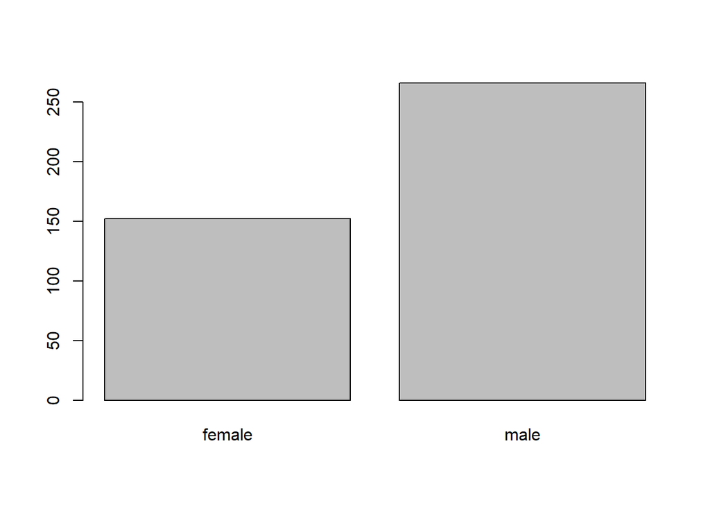

```r
barplot(sex_frequencies)
```

#### There were more male passengers

```r
class_frequencies=table(df$Pclass)
class_frequencies
```

```
##
##   1   2   3
## 107  93 218
```

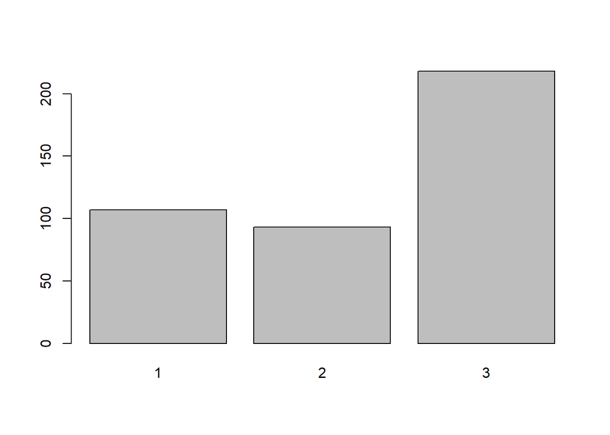

```r
barplot(class_frequencies)
```

#### Most passengers were in 3rd class and the least in 2nd class

```r
survived_frequencies=table(df$Survived)
survived_frequencies
```

```
##
##   0   1
## 266 152
```

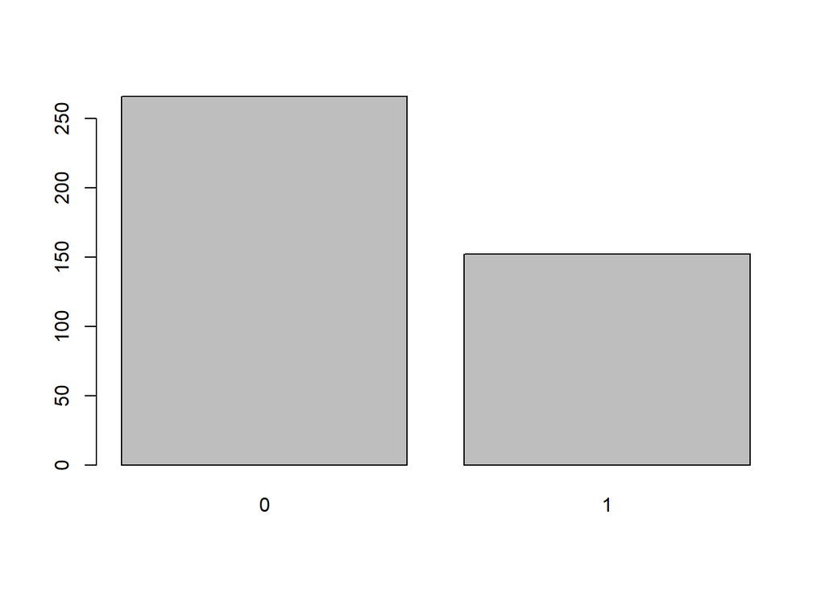

```r
barplot(survived_frequencies)
```

##### 0= did not survive, 1= survived. Majority of the passengers did not survive.

```r
embarked_frequencies=table(df$Embarked)
embarked_frequencies
```

```
##
##   C   Q   S
## 102  46 270
```

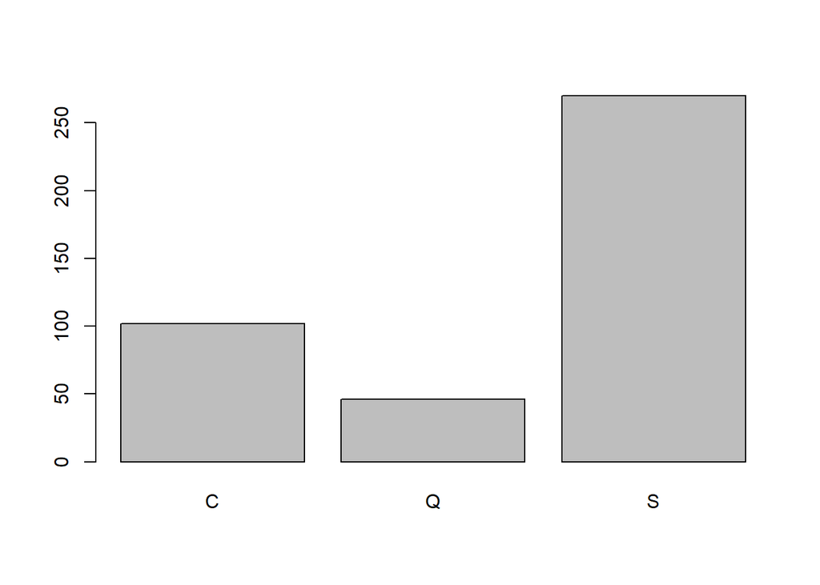

```r
barplot(embarked_frequencies)
```

#### Majority of passengers embarked at station S, followed by C and the least at Q

```r
#place age into categories and fing the frequencies
age_categories <- cut(df$Age,
                      breaks = c(0, 18, 30, 50, max(df$Age, na.rm = TRUE)),
                      labels = c("0-18", "19-30", "31-50", "51+"),
                      include.lowest = TRUE,
                      right = FALSE)
age_frequencies=table(age_categories)
age_frequencies
```

```
## age_categories
##  0-18 19-30 31-50   51+
##    41   221   120    36
```

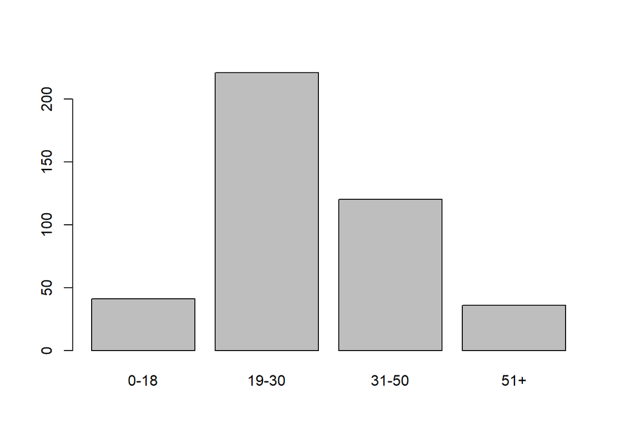

```r
barplot(age_frequencies)
```

```r
##place fare into categories and find frequencies
fare_categories <- cut(df$Fare,
                       breaks = c(0, 10, 30, 50, 100, max(df$Fare, na.rm = TRUE)),
                       labels = c("0-10", "11-30", "31-50", "51-100", "101+"),
                       include.lowest = TRUE,
                       right = FALSE)

fare_frequencies=table(fare_categories)
fare_frequencies
```

```
## fare_categories
##   0-10  11-30  31-50 51-100   101+
##    155    152     30     50     31
```

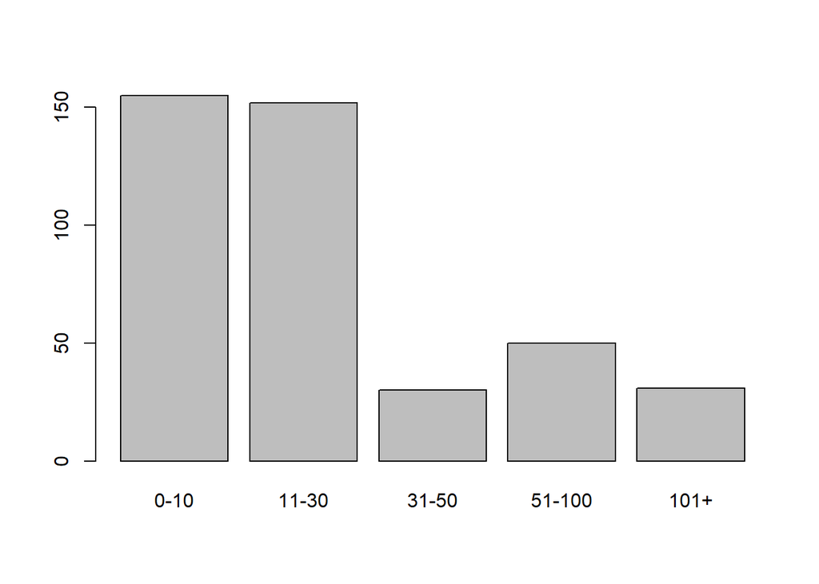

```r
barplot(fare_frequencies)
```

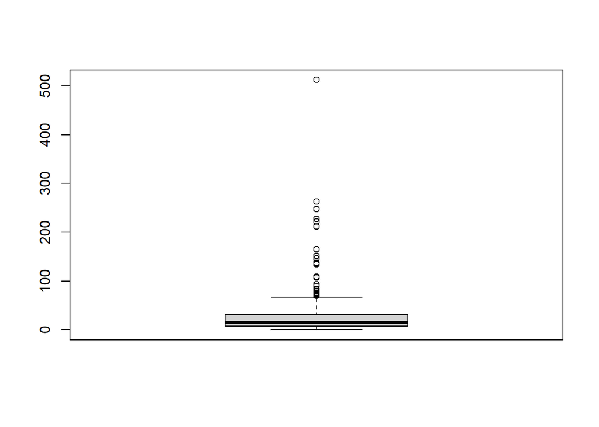

```r
boxplot(df$Fare)
```

##### Majority of the passenger’s fare ranged from 0-30.

# HYPOTHESIS TESTING

## HYPOTHESIS 1

### Ho:There is no statistical and significant difference between the ages of survivors vs non-survivors

### H1:The mean age of survivors is less than the mean age for non-survivors(A higher number of young people survived)

```r
library(dplyr)
survivors=filter(df, df$Survived==1)
head(survivors)
```

```
##   Survived Pclass    Sex Age SibSp Parch    Fare Embarked
## 1        1      3 female  47     1     0  7.0000        S
## 2        1      3 female  22     1     1 12.2875        S
## 3        1      3 female  30     0     0  7.6292        Q
## 4        1      3 female  18     0     0  7.2292        C
## 5        1      1 female  23     1     0 82.2667        S
## 6        1      1 female  47     1     0 61.1750        S
```

```r
non_survivors=filter(df,df$Survived==0)
head(non_survivors)
```

```
##   Survived Pclass  Sex  Age SibSp Parch    Fare Embarked
## 1        0      3 male 34.5     0     0  7.8292        Q
## 2        0      2 male 62.0     0     0  9.6875        Q
## 3        0      3 male 27.0     0     0  8.6625        S
## 4        0      3 male 14.0     0     0  9.2250        S
## 5        0      2 male 26.0     1     1 29.0000        S
## 6        0      3 male 21.0     2     0 24.1500        S
```

```r
##performing t-test
t_test_age<- t.test(survivors$Age, non_survivors$Age,
                    alternative='less',
                    paired=FALSE)
t_test_age
```

```
##
##  Welch Two Sample t-test
##
## data:  survivors$Age and non_survivors$Age
## t = 0.10306, df = 274.19, p-value = 0.541
## alternative hypothesis: true difference in means is less than 0
## 95 percent confidence interval:
##      -Inf 2.420129
## sample estimates:
## mean of x mean of y
##  29.49881  29.35656
```

### Interpretation:The p-value is 0.541, which is larger than 0.05. Therefore, we fail to reject the null hypothesis

### Conclusion: There is no statistical and significant difference in the ages of survivors vs non survivors.The differences are due to random variation

## HYPOTHESIS 2

### Ho:There is no association between survival rate and passenger class

### H1: There is a statistical and significant association between survival rate and passenger class

```r
#contingency table
contingency_table=table(df$Survived, df$Pclass)
contingency_table
```

```
##
##       1   2   3
##   0  57  63 146
##   1  50  30  72
```

```r
#chi-square test
chisq.test(contingency_table)
```

```
##
##  Pearson's Chi-squared test
##
## data:  contingency_table
## X-squared = 6.6939, df = 2, p-value = 0.03519
```

### Interpretation: Since the p-value is 0.03, which is below 0.05, we have sufficient evidence to reject the null hypothesis

### Therefore we conclude that there is a significant association between passenger class and survival rate

```r
##Determining which passenger class had a higher survival rate
survival_percentages = with(df, prop.table(table(Pclass, Survived), margin = 1) * 100)
survival_percentages
```

```
##       Survived
## Pclass        0        1
##      1 53.27103 46.72897
##      2 67.74194 32.25806
##      3 66.97248 33.02752
```

### Conclusion: Passengers in 1st class had a higher survival rate. Survival in 2nd and 3rd class was similar.(0= did not survived, 1= survived)

## HYPOTHESIS 3

### Ho: There is no association between sex and survival rate

### H1: There is a statistical and significant association between sex and survival rate

```r
# Convert "Sex" to binary (0 for male, 1 for female)
df$Sex <- ifelse(df$Sex == "male", 0, 1)
head(df)
```

```
##   Survived Pclass Sex  Age SibSp Parch    Fare Embarked
## 1        0      3   0 34.5     0     0  7.8292        Q
## 2        1      3   1 47.0     1     0  7.0000        S
## 3        0      2   0 62.0     0     0  9.6875        Q
## 4        0      3   0 27.0     0     0  8.6625        S
## 5        1      3   1 22.0     1     1 12.2875        S
## 6        0      3   0 14.0     0     0  9.2250        S
```

```r
#contingency table
contingency_table_sex=table(df$Sex,df$Survived)
contingency_table_sex
```

```
##
##       0   1
##   0 266   0
##   1   0 152
```

```r
#performing chi-square test
chisq.test(contingency_table_sex)
```

```
##
##  Pearson's Chi-squared test with Yates' continuity correction
##
## data:  contingency_table_sex
## X-squared = 413.69, df = 1, p-value < 2.2e-16
```

### Therefore, we can conclude that there is a statistical and significant association between survival rate and sex

```r
##Determining which sex had a higher survival rate
sex_survival_percentages = with(df, prop.table(table(Sex, Survived)) * 100)
sex_survival_percentages
```

```
##    Survived
## Sex        0        1
##   0 63.63636  0.00000
##   1  0.00000 36.36364
```

### male =0, female =1

# CONCLUSIONS

### We conclude that the biggest indicator for survival rate was sex, followed by passenger class.

### Females had a higher chance of survival.

### Passengers in 1st class had a higher chance of survival.

### A female passenger in first class was more likely to survive

### A male passenger in 2nd or 3rd class was least likely to survive

### Age did not have an influence on survival rate